# Final Project Pre-analysis and Data Transformations

Author

Aveontae Frazier

# **Data and Project Narrative**

## AREA CODE DATA BY SELECT CITIES

The file `cities_area_codes_final.csv` contains roughly 3700 city-area code pairs from the modern day.

Its variables `city` and `state_or_province`, and `country` provide the name of a city/town and the state/province in which it is located.

`latitude` and `longitude` provide the spatial coordinates of the midpoint of the city/town.

`area_code` provides a modern-day three digit area code assigned to this city.

Some notes:

- because cities now have multiple associated area codes, a city may occur multiple times in the dataset.
- the list is non-exhaustive. That is, not all possible area code/city combinations are included. So, don’t be worried if you do not see your particular city/area code combination.
- Moreover, not all cities/towns in the US are included. This data is just a smattering I was able to dig up, but it should be enough to adequately complete your task.

```r
cities_area_codes_final <- read_csv("data/cities_area_codes_final.csv") |>
  glimpse()
```

```
Rows: 3,699
Columns: 6
$ area_code         <dbl> 201, 201, 201, 201, 201, 201, 201, 201, 201, 201, 20…
$ city              <chr> "Bayonne", "Bergenfield", "Cliffside Park", "Englewo…
$ state_or_province <chr> "New Jersey", "New Jersey", "New Jersey", "New Jerse…
$ country           <chr> "US", "US", "US", "US", "US", "US", "US", "US", "US"…
$ latitude          <dbl> 40.66871, 40.92760, 40.82149, 40.89288, 40.94038, 40…
$ longitude         <dbl> -74.11431, -73.99736, -73.98764, -73.97264, -74.1318…
```

## COUNTY CENSUS INFO

The file `county_census_info.csv` contains helpful info assembled from the 1950 census, as well as some additional helpful information.

It contains 3123 rows, one for each county in the USA at the time.

The variable `state_name` provides the name of the state in upper case.

The variable `state_fips_code` provides the unqiue two-digit [Federal Information Processing System](https://transition.fcc.gov/oet/info/maps/census/fips/fips.txt) code assigned to the state.

Likewise, the variable `county_name` provides the name of the county, and the variable `county_fips_code` provides the unique three-digit county suffix for each individual county within its state.

These FIPS codes are helpful because they are easier to match than county names which are harder to standardize, and may change over time.

The variable `population_1950` provides the total population in the county as estimated by the 1950 census. Likewise, the variables `population_under5_1950`, `population_over65_1950`, and `black_pop` give the count of people aged below 5, above 65, and identified as Black/African American in the census.

The variable `residence_telephones_1945` provides the number of telephones in the county as 1945 (I was unable to find 1950 data).

The variable `births` provides the number of births in the county in 1950.

```r
county_census_info <- read_csv("data/county_census_info.csv") |>
  mutate(across(ends_with("name"), str_to_lower)) |> #lower state and county
  glimpse()
```

```
Rows: 3,123
Columns: 10
$ state_name                <chr> "alabama", "alabama", "alabama", "alabama", …
$ state_fips_code           <chr> "01", "01", "01", "01", "01", "01", "01", "0…
$ county_fips_code          <chr> "001", "003", "005", "007", "009", "011", "0…
$ county_name               <chr> "autauga", "baldwin", "barbour", "bibb", "bl…
$ population_1950           <dbl> 18186, 40997, 28892, 17987, 28975, 16054, 29…
$ residence_telephones_1945 <dbl> 274, 1026, 711, 191, 308, 253, 636, 3423, 20…
$ population_under5_1950    <dbl> 2342, 5449, 3984, 2286, 3513, 2179, 3859, 99…
$ population_over65_1950    <dbl> 1510, 3030, 2033, 1408, 1904, 1458, 2231, 43…
$ births                    <dbl> 510, 1312, 608, 332, 504, 366, 592, 2364, 78…
$ black_pop                 <dbl> 8366, 9224, 15428, 5828, 811, 11816, 13094, …
```

## SIMPLE FEATURES SHAPE FILE FOR US COUNTIES

The folder `co99_d00_shp` contains the shape file `co99_d00.shp` for the simple features map of the counties of the US.

In it, possibly relevant variables include:

- `AREA`: the area of the region in terms of thousands of square kilometers.
- `STATE`: providing the state FIPS code.
- `COUNTY`: providing the county FIPS code.
- `NAME`: Providing the name of the county
- `geometry` containing the simple features object of the area.

Note that this file contains states (like Alaska) and territories that will need to be excluded from the analysis. Also, some counties are split across multiple rows.

```r
counties_sf <- st_read("data/co99_d00_shp/co99_d00.shp") |>
  glimpse()
```

```
Rows: 3,489
Columns: 10
$ AREA       <dbl> 52.913414742, 74.225062969, 19.679177751, 10.691718052, 0.0…
$ PERIMETER  <dbl> 60.5649616, 63.1309961, 40.9140725, 31.5568732, 0.3498405, …
$ CO99_D00_  <dbl> 2, 3, 4, 5, 6, 7, 8, 9, 10, 11, 12, 13, 14, 15, 16, 17, 18,…
$ CO99_D00_I <dbl> 1, 2, 3, 4, 5, 6, 7, 8, 9, 10, 11, 12, 13, 14, 15, 16, 17, …
$ STATE      <chr> "02", "02", "02", "02", "02", "02", "02", "02", "02", "02",…
$ COUNTY     <chr> "185", "290", "188", "180", "180", "240", "180", "090", "18…
$ NAME       <chr> "North Slope", "Yukon-Koyukuk", "Northwest Arctic", "Nome",…
$ LSAD       <chr> "04", "05", "04", "05", "05", "05", "05", "04", "05", "04",…
$ LSAD_TRANS <chr> "Borough", "Census Area", "Borough", "Census Area", "Census…
$ geometry   <POLYGON> POLYGON ((-147.7871 70.2453..., POLYGON ((-146.9721 68.…
```

## SPLITS AND OVERLAYS DATA

Recall that many of the original area codes now have new “descendant” area codes that were added to the region by process of either split or overlay.

The spreadsheet `splits_overlays.xlsx` contains on sheet for each of the original american area codes, labeled by the three digit area code. Within each sheet, there is a row for each of the current area codes now occupying that original region.

The column `code` provides the code, the column `year` provides the year that code was first used, the column `original` is a logical variable specifying whether or not it was the original area code for this region, and the `territory` variable gives a description of the area covered by the code today.

Note: I do not intend for you to have to use the `year` or `territory` variables in your analysis.

```r
splits_overlays_203 <- read_xlsx("data/splits_overlays.xlsx",
                                  sheet = "203") |> #try sheet #2
  glimpse()
```

```
Rows: 3
Columns: 4
$ code      <chr> "203", "860", "959"
$ year      <dbl> 1947, 1995, 2014
$ original  <lgl> TRUE, FALSE, FALSE
$ territory <chr> "Southwestern Connecticut (Bridgeport, Danbury, New Haven, W…
```

## NEW COUNTIES AND MERGED COUNTIES

Depending on how your approach your data merging, these files might be helpful at reconciling issues:

Since 1947, some counties have ceased to exist, and others have been created.

For those 16 counties that have ceased to exist, they have each been merged into another county. The file `merged_counties_since_1950.csv` contains a row for each county that got eliminated.

The variables `county_name`, `state_fips` and `state_name` provides the name, state fips code, and state of the county that was eliminated. The variable `old_county_fips` provides its fips code before it was eliminated. The variable `new_county_fips` provides the fips code of the county it was merged into.

For the two new counties that have been created, they were both created by breaking off a piece of existing counties.

The file `new_counties_since_1950.csv` contains a row for each. The variables `state`, `state_fips`, `old_county_name` and `old_county_fips` provide the name and FIPS of both the state and county where the separation happened, and the variables `new_county_name` and `new_county_fips` provide the name and FIPS for the new county that was created.

```r
#Read in and clean data
merged_counties_since_1950 <- read.csv("data/merged_counties_since_1950.csv") |>
  mutate(state = str_to_lower(state_name),
         county = str_to_lower(county_name)) |>
  mutate(across(ends_with("fips"), as.character)) |> # for consistency
  select(-c(state_name,
            county_name)) |>
  glimpse()
```

```
Rows: 16
Columns: 5
$ state_fips      <chr> "13", "30", "32", "46", "46", "46", "51", "51", "51", …
$ old_county_fips <chr> "510", "113", "25", "1", "131", "133", "55", "123", "1…
$ new_county_fips <chr> "121", "111", "510", "3", "71", "93", "550", "800", "7…
$ state           <chr> "georgia", "montana", "nevada", "south dakota", "south…
$ county          <chr> "columbus city", "yellowstone nat.", "ormsby", "armstr…
```

```r
new_counties_since_1950 <- read.csv("data/new_counties_since_1950.csv") |>
  mutate(state = str_to_lower(state),
         new_county_name = str_to_lower(new_county_name),
         old_county_name = str_to_lower(old_county_name)) |>
  mutate(across(ends_with("fips"), as.character)) |> # for consistency
  glimpse()
```

```
Rows: 2
Columns: 6
$ state           <chr> "new mexico", "arizona"
$ state_fips      <chr> "35", "4"
$ new_county_name <chr> "cibola", "la paz"
$ new_county_fips <chr> "6", "12"
$ old_county_name <chr> "valencia", "yuma"
$ old_county_fips <chr> "61", "27"
```

# **Pre-Analysis**

## *Merge Current and Old Area Codes*

```r
print(cities_area_codes_final, n = 20) #take a look at the area code dataset
```

```
# A tibble: 3,699 × 6
   area_code city           state_or_province    country latitude longitude
       <dbl> <chr>          <chr>                <chr>      <dbl>     <dbl>
 1       201 Bayonne        New Jersey           US          40.7     -74.1
 2       201 Bergenfield    New Jersey           US          40.9     -74.0
 3       201 Cliffside Park New Jersey           US          40.8     -74.0
 4       201 Englewood      New Jersey           US          40.9     -74.0
 5       201 Fair Lawn      New Jersey           US          40.9     -74.1
 6       201 Fort Lee       New Jersey           US          40.9     -74.0
 7       201 Hackensack     New Jersey           US          40.9     -74.0
 8       201 Hoboken        New Jersey           US          40.7     -74.0
 9       201 Jersey City    New Jersey           US          40.7     -74.1
10       201 Kearny         New Jersey           US          40.8     -74.1
11       201 North Bergen   New Jersey           US          40.8     -74.0
12       201 Paramus        New Jersey           US          40.9     -74.1
13       201 Ridgewood      New Jersey           US          41.0     -74.1
14       201 Teaneck        New Jersey           US          40.9     -74.0
15       201 Union City     New Jersey           US          40.8     -74.0
16       201 West New York  New Jersey           US          40.8     -74.0
17       202 Washington     District of Columbia US          38.9     -77.0
18       203 Bridgeport     Connecticut          US          41.2     -73.2
19       203 Danbury        Connecticut          US          41.4     -73.5
20       203 East Haven     Connecticut          US          41.3     -72.9
# ℹ 3,679 more rows
```

```r
cities_area_codes_final <- cities_area_codes_final |>
  filter(country == "US") #save just the US

print(splits_overlays_203) #look at one older area code
```

```
# A tibble: 3 × 4
  code   year original territory
  <chr> <dbl> <lgl>    <chr>
1 203    1947 TRUE     Southwestern Connecticut (Bridgeport, Danbury, New Haven…
2 860    1995 FALSE    Northern and eastern Connecticut (Hartford, Bristol, Nor…
3 959    2014 FALSE    Northern and eastern Connecticut (Hartford, Bristol, Nor…
```

```r
# Will scrape the original area codes from the internet
# url: https://en.wikipedia.org/wiki/Original_North_American_area_codes

url <- "https://en.wikipedia.org/wiki/Original_North_American_area_codes"

html <- url |>
  read_html()

html
```

```
{html_document}
<html class="client-nojs vector-feature-language-in-header-enabled vector-feature-language-in-main-page-header-disabled vector-feature-sticky-header-disabled vector-feature-page-tools-pinned-disabled vector-feature-toc-pinned-clientpref-1 vector-feature-main-menu-pinned-disabled vector-feature-limit…
[1] <head>\n<meta http-equiv="Content-Type" content="text/html; charset=UTF-8 ...
[2] <body class="skin--responsive skin-vector skin-vector-search-vue mediawik ...
```

```r
original_area_codes_table_html <- html_table(html)

original_area_codes_table_html  |>
  class()
```

```
[1] "list"
```

```r
original_area_codes_table <- original_area_codes_table_html[[2]] #second table

original_area_codes <- original_area_codes_table |>
  clean_names() |>
  pull(area_code)

original_area_codes
```

```
 [1] 201 202 203 204 205 206 207 208 212 213 214 215 216 217 218 301 302 303 304
[20] 305 306 307 312 313 314 315 316 317 319 401 402 403 404 405 406 412 413 414
[39] 415 416 418 419 501 502 503 504 505 512 513 514 515 517 518 601 602 603 604
[58] 605 612 613 614 616 617 618 701 702 703 704 712 713 715 716 717 801 802 803
[77] 812 814 815 816 901 902 913 914 915 916
```

```r
n_distinct(original_area_codes) #expected number of area codes!
```

```
[1] 86
```

```r
# Remove Area Codes in conflict with splits overlays csv
area_codes_to_exclude <- c(204,
                           306,
                           403,
                           418,
                           514,
                           604,
                           613,
                           416,
                           902)

area_code_table <-tibble(original_area_code = as.character(original_area_codes)) |>
  filter(!original_area_codes %in% area_codes_to_exclude) |> #remove
  glimpse()
```

```
Rows: 77
Columns: 1
$ original_area_code <chr> "201", "202", "203", "205", "206", "207", "208", "2…
```

```r
# Read in the split overlay data
area_code_table <- area_code_table |>
  rowwise() |>
  mutate(splits_overlays = list(read_xlsx("data/splits_overlays.xlsx",
                                  sheet = original_area_code))) |>
  unnest(splits_overlays) #unnest to get nice result

# Prepare data
area_code_table <- area_code_table |>
  select(original_area_code, # Get rid of year and territory
         code,
         original) |>
  rename(new_area_code = code) |> #new area code
  mutate(original_area_code = as.integer(original_area_code), #convert to int for later
         new_area_code = as.integer(new_area_code)) |>
  glimpse()
```

```
Rows: 297
Columns: 3
$ original_area_code <int> 201, 201, 201, 201, 201, 201, 201, 201, 201, 202, 2…
$ new_area_code      <int> 201, 551, 609, 732, 848, 856, 862, 908, 973, 202, 2…
$ original           <lgl> TRUE, FALSE, FALSE, FALSE, FALSE, FALSE, FALSE, FAL…
```

```r
# Add the codes_created to count number of new area codes per original area code
area_code_table_counts <- area_code_table |>
  group_by(original_area_code) |>
  mutate(n_codes_created = (n_distinct(new_area_code))) |>
  ungroup() |> # Remove grouping to return to regular data frame
  distinct(original_area_code,
         n_codes_created) |>
  glimpse()
```

```
Rows: 77
Columns: 2
$ original_area_code <int> 201, 202, 203, 205, 206, 207, 208, 212, 213, 214, 2…
$ n_codes_created    <int> 9, 1, 3, 4, 5, 1, 1, 6, 19, 8, 4, 4, 2, 2, 5, 1, 4,…
```

```r
# Write area_code_table_counts to csv
# write_csv(area_code_table_counts, "data/area_code_table_counts_final.csv")
```

```r
# Merge data with the current area code data
cities_area_codes_final |>
  glimpse()
```

```
Rows: 2,703
Columns: 6
$ area_code         <dbl> 201, 201, 201, 201, 201, 201, 201, 201, 201, 201, 20…
$ city              <chr> "Bayonne", "Bergenfield", "Cliffside Park", "Englewo…
$ state_or_province <chr> "New Jersey", "New Jersey", "New Jersey", "New Jerse…
$ country           <chr> "US", "US", "US", "US", "US", "US", "US", "US", "US"…
$ latitude          <dbl> 40.66871, 40.92760, 40.82149, 40.89288, 40.94038, 40…
$ longitude         <dbl> -74.11431, -73.99736, -73.98764, -73.97264, -74.1318…
```

```r
cities_area_codes_final <- cities_area_codes_final |>
  mutate(area_code = as.integer(area_code)) #convert for join

cities_area_codes_merged <- cities_area_codes_final |>
  left_join(area_code_table,
            by = join_by(area_code == new_area_code)) |>
  rename(new_area_code = area_code)

# Confirm join worked as expected
cities_area_codes_merged |>
  filter(original == FALSE) |>
  glimpse()
```

```
Rows: 2,081
Columns: 8
$ new_area_code      <int> 209, 209, 209, 209, 209, 209, 209, 209, 209, 209, 2…
$ city               <chr> "Atwater", "Ceres", "Lodi", "Los Banos", "Manteca",…
$ state_or_province  <chr> "California", "California", "California", "Californ…
$ country            <chr> "US", "US", "US", "US", "US", "US", "US", "US", "US…
$ latitude           <dbl> 37.34772, 37.59493, 38.13020, 37.05828, 37.79743, 3…
$ longitude          <dbl> -120.60908, -120.95771, -121.27245, -120.84992, -12…
$ original_area_code <int> 916, 916, 916, 916, 916, 916, 916, 916, 916, 916, 5…
$ original           <lgl> FALSE, FALSE, FALSE, FALSE, FALSE, FALSE, FALSE, FA…
```

## *Convert Area Code data frame into Simple Features*

```r
cities_area_codes_merged_sf <- st_as_sf(cities_area_codes_merged,
                                        coords = c("longitude", "latitude"),
                                        crs = st_crs(4269))

counties_sf <- counties_sf |>
  filter(!(counties_sf$STATE %in% c("02", #Alaska
                        "15" #Hawaii
                        )))

counties_sf <- st_set_crs(counties_sf, 4269) # set same CRS for join

# Perform spatial join based on geometry
counties_with_area_codes_sf <- st_join(counties_sf,
                              cities_area_codes_merged_sf,
                              join = st_intersects)

# All the relevant city, state, and county pairings for new and old area codes
counties_with_area_codes <- counties_with_area_codes_sf |>
  select(new_area_code,
         original_area_code,
         original,
         city,
         state_or_province,
         county = NAME,
         state_code = STATE,
         county_code = COUNTY) |>
  st_drop_geometry() |>  #remove the special geometry attribute
  glimpse()
```

```
Rows: 5,309
Columns: 8
$ new_area_code      <int> NA, 360, NA, NA, NA, NA, NA, NA, NA, NA, NA, NA, NA…
$ original_area_code <int> NA, 206, NA, NA, NA, NA, NA, NA, NA, NA, NA, NA, NA…
$ original           <lgl> NA, FALSE, NA, NA, NA, NA, NA, NA, NA, NA, NA, NA, …
$ city               <chr> NA, "Bellingham", NA, NA, NA, NA, NA, NA, NA, NA, N…
$ state_or_province  <chr> NA, "Washington", NA, NA, NA, NA, NA, NA, NA, NA, N…
$ county             <chr> "Lake of the Woods", "Whatcom", "Whatcom", "Flathea…
$ state_code         <chr> "27", "53", "53", "30", "30", "16", "30", "53", "53…
$ county_code        <chr> "077", "073", "073", "029", "053", "021", "005", "0…
```

```r
# Write to csv
# write_csv(counties_with_area_codes, "data/counties_with_area_codes_final.csv")
```

## *Merge Area Code Data with Counties_SF*

```r
# Read in counties simple features
counties_sf <- st_read("data/co99_d00_shp/co99_d00.shp") |>
  glimpse()
```

```
Rows: 3,489
Columns: 10
$ AREA       <dbl> 52.913414742, 74.225062969, 19.679177751, 10.691718052, 0.0…
$ PERIMETER  <dbl> 60.5649616, 63.1309961, 40.9140725, 31.5568732, 0.3498405, …
$ CO99_D00_  <dbl> 2, 3, 4, 5, 6, 7, 8, 9, 10, 11, 12, 13, 14, 15, 16, 17, 18,…
$ CO99_D00_I <dbl> 1, 2, 3, 4, 5, 6, 7, 8, 9, 10, 11, 12, 13, 14, 15, 16, 17, …
$ STATE      <chr> "02", "02", "02", "02", "02", "02", "02", "02", "02", "02",…
$ COUNTY     <chr> "185", "290", "188", "180", "180", "240", "180", "090", "18…
$ NAME       <chr> "North Slope", "Yukon-Koyukuk", "Northwest Arctic", "Nome",…
$ LSAD       <chr> "04", "05", "04", "05", "05", "05", "05", "04", "05", "04",…
$ LSAD_TRANS <chr> "Borough", "Census Area", "Borough", "Census Area", "Census…
$ geometry   <POLYGON> POLYGON ((-147.7871 70.2453..., POLYGON ((-146.9721 68.…
```

```r
# Counties that have data!
counties_with_area_codes_sf |>
  filter(!is.na(original_area_code)) |>
  glimpse()
```

```
Rows: 2,688
Columns: 16
$ AREA               <dbl> 0.6839444, 0.6445464, 0.5493285, 2.0886604, 0.93213…
$ PERIMETER          <dbl> 5.326881, 4.444013, 5.401048, 7.019821, 6.036194, 4…
$ CO99_D00_          <dbl> 116, 145, 151, 154, 159, 171, 171, 171, 171, 171, 1…
$ CO99_D00_I         <dbl> 115, 144, 150, 153, 158, 170, 170, 170, 170, 170, 1…
$ STATE              <chr> "53", "38", "53", "27", "53", "53", "53", "53", "53…
$ COUNTY             <chr> "073", "101", "057", "137", "007", "061", "061", "0…
$ NAME               <chr> "Whatcom", "Ward", "Skagit", "St. Louis", "Chelan",…
$ LSAD               <chr> "06", "06", "06", "06", "06", "06", "06", "06", "06…
$ LSAD_TRANS         <chr> "County", "County", "County", "County", "County", "…
$ new_area_code      <int> 360, 701, 360, 218, 509, 360, 425, 425, 425, 425, 4…
$ city               <chr> "Bellingham", "Minot", "Mount Vernon", "Duluth", "W…
$ state_or_province  <chr> "Washington", "North Dakota", "Washington", "Minnes…
$ country            <chr> "US", "US", "US", "US", "US", "US", "US", "US", "US…
$ original_area_code <int> 206, 701, 206, 218, 206, 206, 206, 206, 206, 206, 2…
$ original           <lgl> FALSE, TRUE, FALSE, TRUE, FALSE, FALSE, FALSE, FALS…
$ geometry           <POLYGON [°]> POLYGON ((-122.2907 49.0024..., POLYGON ((-…
```

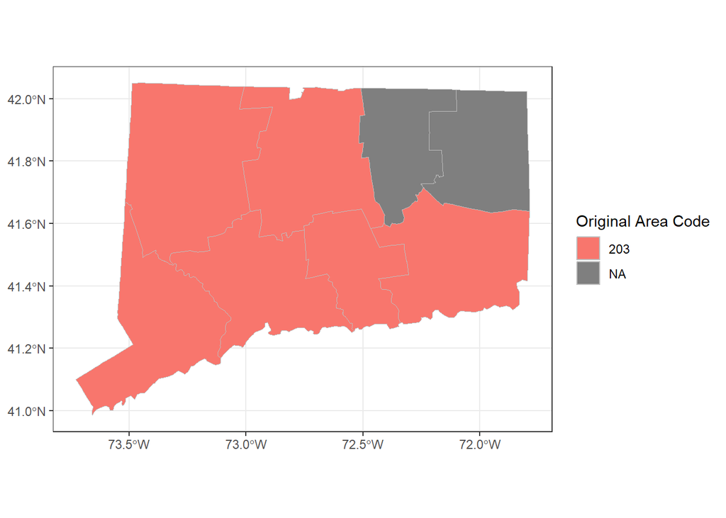

```r
# A list of states to plot, must use state FIPS codes not state_or_province
states_to_plot <- c("09",     # Connecticut
                    "36",     # New York
                    "48",     # Texas
                    "29",     # Missouri
                    "23",     # Maine
                    "55",     # Wisconsin
                    "19")     # Iowa

# Create variables for each state
connecticut <- counties_with_area_codes_sf |>
  filter(STATE == states_to_plot[1])

new_york <- counties_with_area_codes_sf |>
  filter(STATE == states_to_plot[2])

texas <- counties_with_area_codes_sf |>
  filter(STATE == states_to_plot[3])

missouri <- counties_with_area_codes_sf |>
  filter(STATE == states_to_plot[4])

maine <- counties_with_area_codes_sf |>
  filter(STATE == states_to_plot[5])

wisconsin <- counties_with_area_codes_sf |>
  filter(STATE == states_to_plot[6])

iowa <- counties_with_area_codes_sf |>
  filter(STATE == states_to_plot[7])


## Plot states

#Connecticut
ggplot() +
  geom_sf(data = connecticut,
          aes(fill = as.factor(original_area_code)),
          color = "grey") + # fill empty area with grey
  labs(fill = "Original Area Code")
```

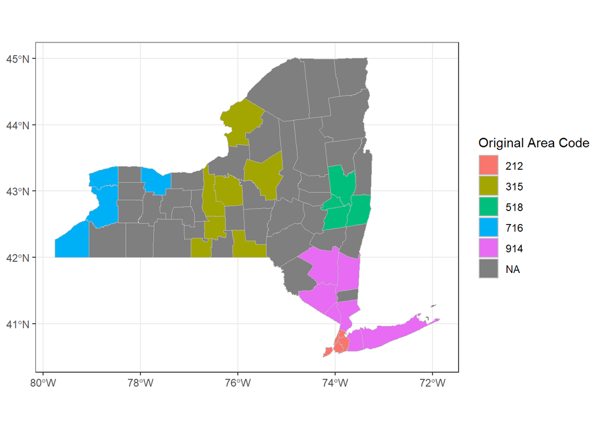

```r
#New York
ggplot() +
  geom_sf(data = new_york,
          aes(fill = as.factor(original_area_code)),
          color = "grey") +
  labs(fill = "Original Area Code")
```

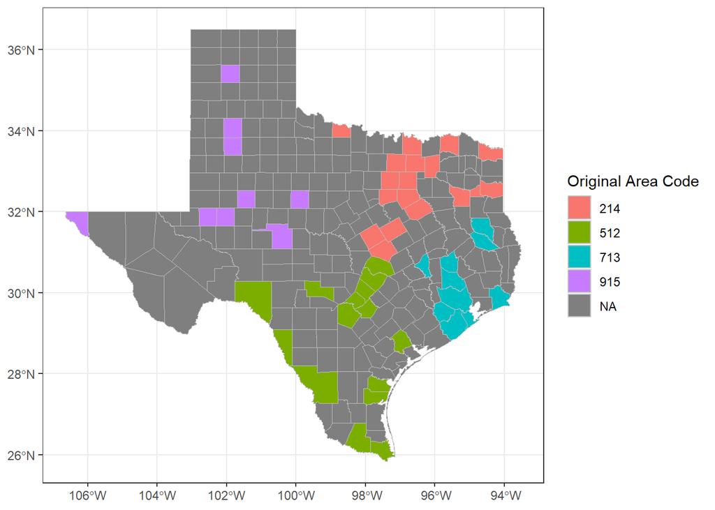

```r
#Texas
ggplot() +
  geom_sf(data = texas,
          aes(fill = as.factor(original_area_code)),
          color = "grey") +
  labs(fill = "Original Area Code")
```

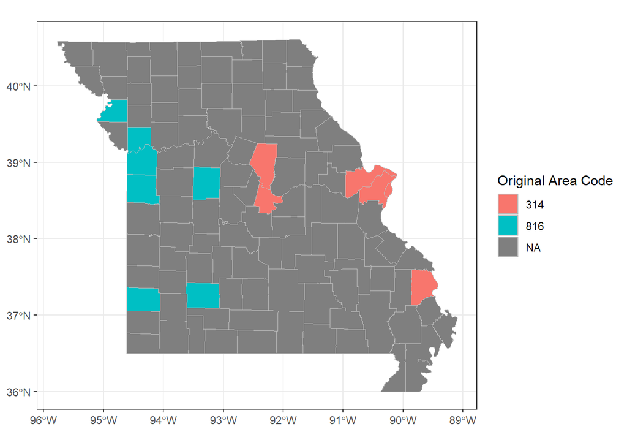

```r
#Missouri
ggplot() +
  geom_sf(data = missouri,
          aes(fill = as.factor(original_area_code)),
          color = "grey") +
  labs(fill = "Original Area Code")
```

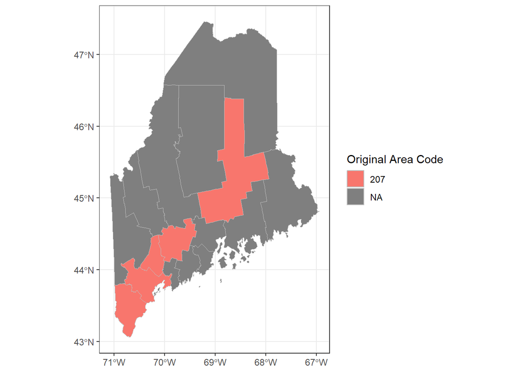

```r
#Maine
ggplot() +
  geom_sf(data = maine,
          aes(fill = as.factor(original_area_code)),
          color = "grey") +
  labs(fill = "Original Area Code")
```

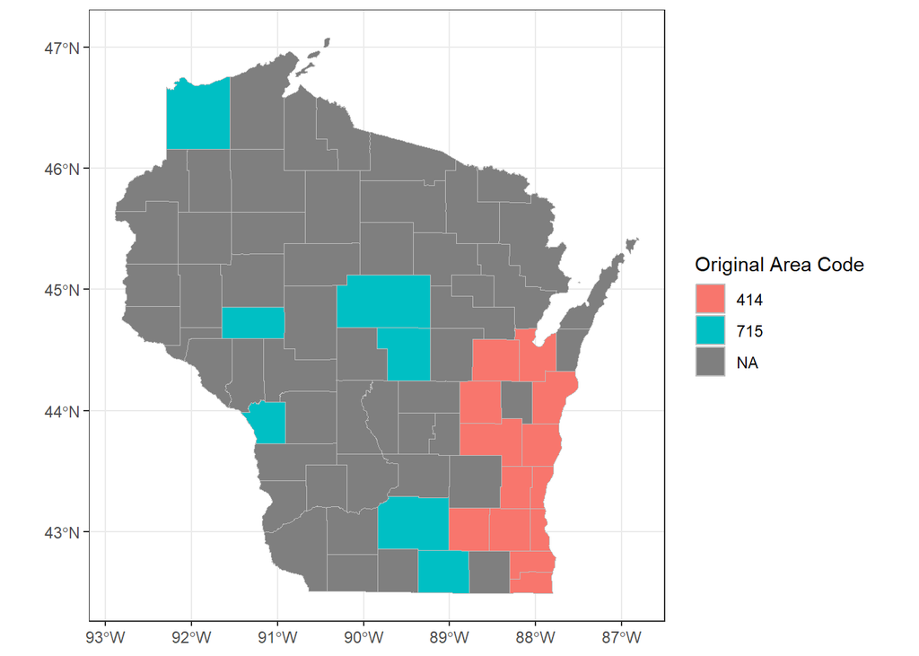

```r
#Wisconsin
ggplot() +
  geom_sf(data = wisconsin,
          aes(fill = as.factor(original_area_code)),
          color = "grey") +
  labs(fill = "Original Area Code")
```

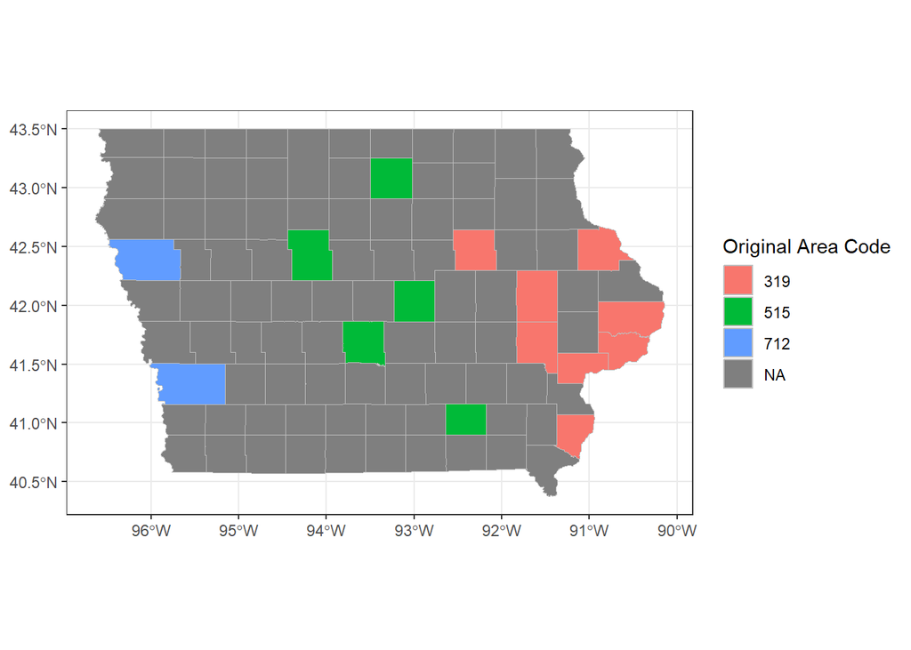

```r
#Final check—Iowa
ggplot() +
  geom_sf(data = iowa,
          aes(fill = as.factor(original_area_code)),
          color = "grey") +
  labs(fill = "Original Area Code")
```

## *Add the location of the center of each shape in the simple features*

```r
counties_with_area_codes_sf <- counties_with_area_codes_sf |>
  mutate(centroid = st_centroid(geometry) |>
           st_coordinates(),
         centroid_lat = centroid[,2],
         centroid_long = centroid[,1]) |>
  mutate(original_area_code = as.factor(original_area_code)) #prepare for modeling
```

## *Impute original area codes for cities without one using the K-nearest neighbors algorithm*

```r
set.seed(3)

## Partition data based on NAs

# Test data are rows with NAs for original_area_codes
test_data <- counties_with_area_codes_sf |>
  filter(is.na(original_area_code)) |>
  glimpse()
```

```
Rows: 2,621
Columns: 19
$ AREA               <dbl> 0.562393279, 0.001520854, 1.649978681, 1.159211730,…
$ PERIMETER          <dbl> 4.2540510, 0.1743605, 8.6585477, 5.6142120, 2.96652…
$ CO99_D00_          <dbl> 115, 117, 118, 119, 120, 121, 122, 123, 124, 125, 1…
$ CO99_D00_I         <dbl> 114, 116, 117, 118, 119, 120, 121, 122, 123, 124, 1…
$ STATE              <chr> "27", "53", "30", "30", "16", "30", "53", "53", "38…
$ COUNTY             <chr> "077", "073", "029", "053", "021", "005", "065", "0…
$ NAME               <chr> "Lake of the Woods", "Whatcom", "Flathead", "Lincol…
$ LSAD               <chr> "06", "06", "06", "06", "06", "06", "06", "06", "06…
$ LSAD_TRANS         <chr> "County", "County", "County", "County", "County", "…
$ new_area_code      <int> NA, NA, NA, NA, NA, NA, NA, NA, NA, NA, NA, NA, NA,…
$ city               <chr> NA, NA, NA, NA, NA, NA, NA, NA, NA, NA, NA, NA, NA,…
$ state_or_province  <chr> NA, NA, NA, NA, NA, NA, NA, NA, NA, NA, NA, NA, NA,…
$ country            <chr> NA, NA, NA, NA, NA, NA, NA, NA, NA, NA, NA, NA, NA,…
$ original_area_code <fct> NA, NA, NA, NA, NA, NA, NA, NA, NA, NA, NA, NA, NA,…
$ original           <lgl> NA, NA, NA, NA, NA, NA, NA, NA, NA, NA, NA, NA, NA,…
$ geometry           <POLYGON [°]> POLYGON ((-95.15332 49.1931..., POLYGON ((-…
$ centroid           <dbl[,2]> <matrix[26 x 2]>
$ centroid_lat       <dbl> 48.76932, 48.98870, 48.29419, 48.54146, 48.7669…
$ centroid_long      <dbl> -94.90434, -123.05693, -114.04726, -115.40528, -116…
```

```r
# Train data are rows with no NAs for original_area_codes
train_data <- counties_with_area_codes_sf |>
  filter(!is.na(original_area_code)) |>
  glimpse()
```

```
Rows: 2,688
Columns: 19
$ AREA               <dbl> 0.6839444, 0.6445464, 0.5493285, 2.0886604, 0.93213…
$ PERIMETER          <dbl> 5.326881, 4.444013, 5.401048, 7.019821, 6.036194, 4…
$ CO99_D00_          <dbl> 116, 145, 151, 154, 159, 171, 171, 171, 171, 171, 1…
$ CO99_D00_I         <dbl> 115, 144, 150, 153, 158, 170, 170, 170, 170, 170, 1…
$ STATE              <chr> "53", "38", "53", "27", "53", "53", "53", "53", "53…
$ COUNTY             <chr> "073", "101", "057", "137", "007", "061", "061", "0…
$ NAME               <chr> "Whatcom", "Ward", "Skagit", "St. Louis", "Chelan",…
$ LSAD               <chr> "06", "06", "06", "06", "06", "06", "06", "06", "06…
$ LSAD_TRANS         <chr> "County", "County", "County", "County", "County", "…
$ new_area_code      <int> 360, 701, 360, 218, 509, 360, 425, 425, 425, 425, 4…
$ city               <chr> "Bellingham", "Minot", "Mount Vernon", "Duluth", "W…
$ state_or_province  <chr> "Washington", "North Dakota", "Washington", "Minnes…
$ country            <chr> "US", "US", "US", "US", "US", "US", "US", "US", "US…
$ original_area_code <fct> 206, 701, 206, 218, 206, 206, 206, 206, 206, 206, 2…
$ original           <lgl> FALSE, TRUE, FALSE, TRUE, FALSE, FALSE, FALSE, FALS…
$ geometry           <POLYGON [°]> POLYGON ((-122.2907 49.0024..., POLYGON ((-…
$ centroid           <dbl[,2]> <matrix[26 x 2]>
$ centroid_lat       <dbl> 48.82708, 48.22115, 48.47923, 47.59933, 47.8676…
$ centroid_long      <dbl> -121.71342, -101.54041, -121.72178, -92.46982, -120…
```

```r
# Create workflow
rknn_recipe <- recipe(original_area_code ~ STATE + centroid_lat + centroid_long,
                      data = train_data) |>
  step_other(STATE, threshold = 0.001) |>
  step_dummy(all_nominal_predictors()) |>
  step_normalize(all_predictors())


classification_rknn <- nearest_neighbor(neighbors = 1,
                                 weight_func = "rectangular") |>
  set_engine("kknn") |>
  set_mode("classification")

workflow_rknn <- workflow() |>
  add_model(classification_rknn) |>
  add_recipe(rknn_recipe)

# Fit the model
workflow_rknn_fit <- workflow_rknn |>
  fit(train_data)

# Predict the original area code on the test partition
workflow_rknn_preds <- workflow_rknn_fit |>
  predict(test_data)

workflow_rknn_preds
```

```
# A tibble: 2,621 × 1
   .pred_class
   <fct>
 1 218
 2 206
 3 406
 4 406
 5 208
 6 406
 7 206
 8 206
 9 701
10 218
# ℹ 2,611 more rows
```

```r
## To assess model performance, I will check the accuracy of predictions against the train partition

# Predict on training data
train_predictions <- workflow_rknn_fit |>
  predict(train_data) |>
  bind_cols(train_data)  #combine predictions with actual data for comparison

# Assess accuracy
accuracy <- mean(train_predictions$.pred_class == train_predictions$original_area_code)
str_glue("Training Accuracy: {accuracy*100}%")
```

```
Training Accuracy: 100%
```

```r
# Merge the predictions with the test data
imputed_data <- test_data |>
  bind_cols(workflow_rknn_preds) |>
  select(-original_area_code) |>  #drop NAs
  rename(original_area_code = .pred_class)

train_data |>
  glimpse()
```

```
Rows: 2,688
Columns: 19
$ AREA               <dbl> 0.6839444, 0.6445464, 0.5493285, 2.0886604, 0.93213…
$ PERIMETER          <dbl> 5.326881, 4.444013, 5.401048, 7.019821, 6.036194, 4…
$ CO99_D00_          <dbl> 116, 145, 151, 154, 159, 171, 171, 171, 171, 171, 1…
$ CO99_D00_I         <dbl> 115, 144, 150, 153, 158, 170, 170, 170, 170, 170, 1…
$ STATE              <chr> "53", "38", "53", "27", "53", "53", "53", "53", "53…
$ COUNTY             <chr> "073", "101", "057", "137", "007", "061", "061", "0…
$ NAME               <chr> "Whatcom", "Ward", "Skagit", "St. Louis", "Chelan",…
$ LSAD               <chr> "06", "06", "06", "06", "06", "06", "06", "06", "06…
$ LSAD_TRANS         <chr> "County", "County", "County", "County", "County", "…
$ new_area_code      <int> 360, 701, 360, 218, 509, 360, 425, 425, 425, 425, 4…
$ city               <chr> "Bellingham", "Minot", "Mount Vernon", "Duluth", "W…
$ state_or_province  <chr> "Washington", "North Dakota", "Washington", "Minnes…
$ country            <chr> "US", "US", "US", "US", "US", "US", "US", "US", "US…
$ original_area_code <fct> 206, 701, 206, 218, 206, 206, 206, 206, 206, 206, 2…
$ original           <lgl> FALSE, TRUE, FALSE, TRUE, FALSE, FALSE, FALSE, FALS…
$ geometry           <POLYGON [°]> POLYGON ((-122.2907 49.0024..., POLYGON ((-…
$ centroid           <dbl[,2]> <matrix[26 x 2]>
$ centroid_lat       <dbl> 48.82708, 48.22115, 48.47923, 47.59933, 47.8676…
$ centroid_long      <dbl> -121.71342, -101.54041, -121.72178, -92.46982, -120…
```

```r
imputed_data |>
  glimpse()
```

```
Rows: 2,621
Columns: 19
$ AREA               <dbl> 0.562393279, 0.001520854, 1.649978681, 1.159211730,…
$ PERIMETER          <dbl> 4.2540510, 0.1743605, 8.6585477, 5.6142120, 2.96652…
$ CO99_D00_          <dbl> 115, 117, 118, 119, 120, 121, 122, 123, 124, 125, 1…
$ CO99_D00_I         <dbl> 114, 116, 117, 118, 119, 120, 121, 122, 123, 124, 1…
$ STATE              <chr> "27", "53", "30", "30", "16", "30", "53", "53", "38…
$ COUNTY             <chr> "077", "073", "029", "053", "021", "005", "065", "0…
$ NAME               <chr> "Lake of the Woods", "Whatcom", "Flathead", "Lincol…
$ LSAD               <chr> "06", "06", "06", "06", "06", "06", "06", "06", "06…
$ LSAD_TRANS         <chr> "County", "County", "County", "County", "County", "…
$ new_area_code      <int> NA, NA, NA, NA, NA, NA, NA, NA, NA, NA, NA, NA, NA,…
$ city               <chr> NA, NA, NA, NA, NA, NA, NA, NA, NA, NA, NA, NA, NA,…
$ state_or_province  <chr> NA, NA, NA, NA, NA, NA, NA, NA, NA, NA, NA, NA, NA,…
$ country            <chr> NA, NA, NA, NA, NA, NA, NA, NA, NA, NA, NA, NA, NA,…
$ original           <lgl> NA, NA, NA, NA, NA, NA, NA, NA, NA, NA, NA, NA, NA,…
$ centroid           <dbl[,2]> <matrix[26 x 2]>
$ centroid_lat       <dbl> 48.76932, 48.98870, 48.29419, 48.54146, 48.7669…
$ centroid_long      <dbl> -94.90434, -123.05693, -114.04726, -115.40528, -116…
$ original_area_code <fct> 218, 206, 406, 406, 208, 406, 206, 206, 701, 218, 4…
$ geometry           <POLYGON [°]> POLYGON ((-95.15332 49.1931..., POLYGON ((-123.0905…
```

```r
# Combine train_data with the imputed data
counties_area_codes_sf_imputed <- bind_rows(train_data,
                                            imputed_data) |>
  glimpse()
```

```
Rows: 5,309
Columns: 19
$ AREA               <dbl> 0.6839444, 0.6445464, 0.5493285, 2.0886604, 0.93213…
$ PERIMETER          <dbl> 5.326881, 4.444013, 5.401048, 7.019821, 6.036194, 4…
$ CO99_D00_          <dbl> 116, 145, 151, 154, 159, 171, 171, 171, 171, 171, 1…
$ CO99_D00_I         <dbl> 115, 144, 150, 153, 158, 170, 170, 170, 170, 170, 1…
$ STATE              <chr> "53", "38", "53", "27", "53", "53", "53", "53", "53…
$ COUNTY             <chr> "073", "101", "057", "137", "007", "061", "061", "0…
$ NAME               <chr> "Whatcom", "Ward", "Skagit", "St. Louis", "Chelan",…
$ LSAD               <chr> "06", "06", "06", "06", "06", "06", "06", "06", "06…
$ LSAD_TRANS         <chr> "County", "County", "County", "County", "County", "…
$ new_area_code      <int> 360, 701, 360, 218, 509, 360, 425, 425, 425, 425, 4…
$ city               <chr> "Bellingham", "Minot", "Mount Vernon", "Duluth", "W…
$ state_or_province  <chr> "Washington", "North Dakota", "Washington", "Minnes…
$ country            <chr> "US", "US", "US", "US", "US", "US", "US", "US", "US…
$ original_area_code <fct> 206, 701, 206, 218, 206, 206, 206, 206, 206, 206, 2…
$ original           <lgl> FALSE, TRUE, FALSE, TRUE, FALSE, FALSE, FALSE, FALS…
$ centroid           <dbl[,2]> <matrix[26 x 2]>
$ centroid_lat       <dbl> 48.82708, 48.22115, 48.47923, 47.59933, 47.8676…
$ centroid_long      <dbl> -121.71342, -101.54041, -121.72178, -92.46982, -120…
$ geometry           <POLYGON [°]> POLYGON ((-122.2907 49.0024..., POLYGON ((-102.1521…
```

## *Check to determine whether states are imputed properly*

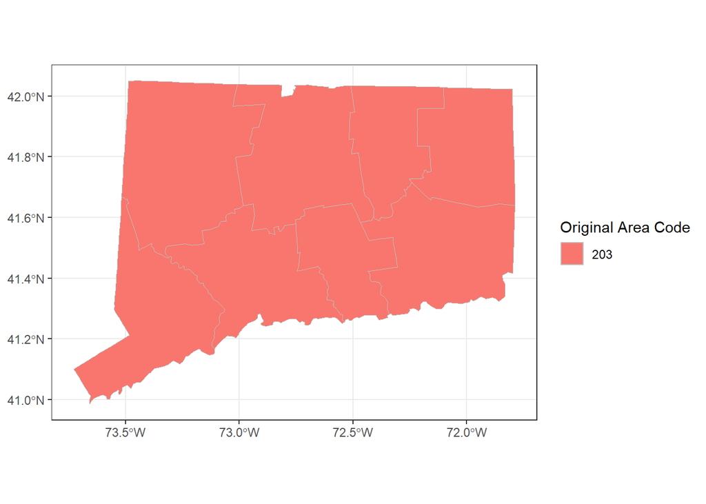

```r
# Modify state variables
connecticut2 <- counties_area_codes_sf_imputed |>
  filter(STATE == states_to_plot[1])

new_york2 <- counties_area_codes_sf_imputed |>
  filter(STATE == states_to_plot[2])

texas2 <- counties_area_codes_sf_imputed |>
  filter(STATE == states_to_plot[3])

missouri2 <- counties_area_codes_sf_imputed |>
  filter(STATE == states_to_plot[4])

maine2 <- counties_area_codes_sf_imputed |>
  filter(STATE == states_to_plot[5])

wisconsin2 <- counties_area_codes_sf_imputed |>
  filter(STATE == states_to_plot[6])

iowa2 <- counties_area_codes_sf_imputed |>
  filter(STATE == states_to_plot[7])

## Plot states

#Connecticut
ggplot() +
  geom_sf(data = connecticut2,
          aes(fill = as.factor(original_area_code)),
          color = "grey") + # fill empty area with grey
  labs(fill = "Original Area Code")
```

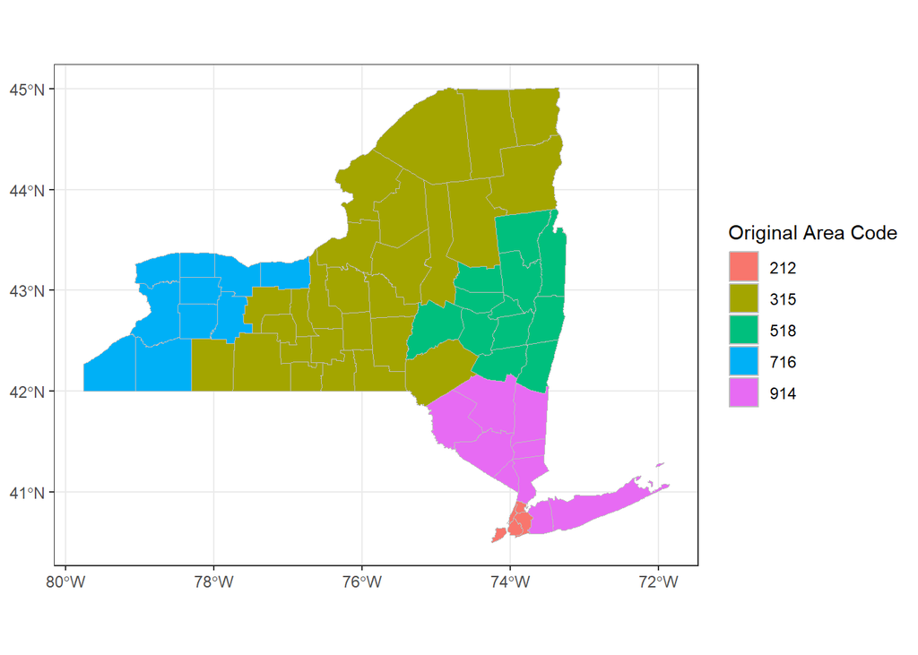

```r
#New York
ggplot() +
  geom_sf(data = new_york2,
          aes(fill = as.factor(original_area_code)),
          color = "grey") +
  labs(fill = "Original Area Code")
```

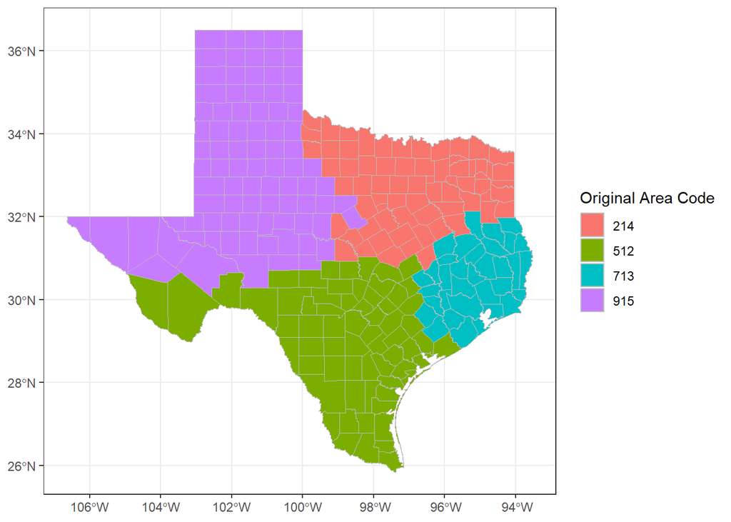

```r
#Texas
ggplot() +
  geom_sf(data = texas2,
          aes(fill = as.factor(original_area_code)),
          color = "grey") +
  labs(fill = "Original Area Code")
```

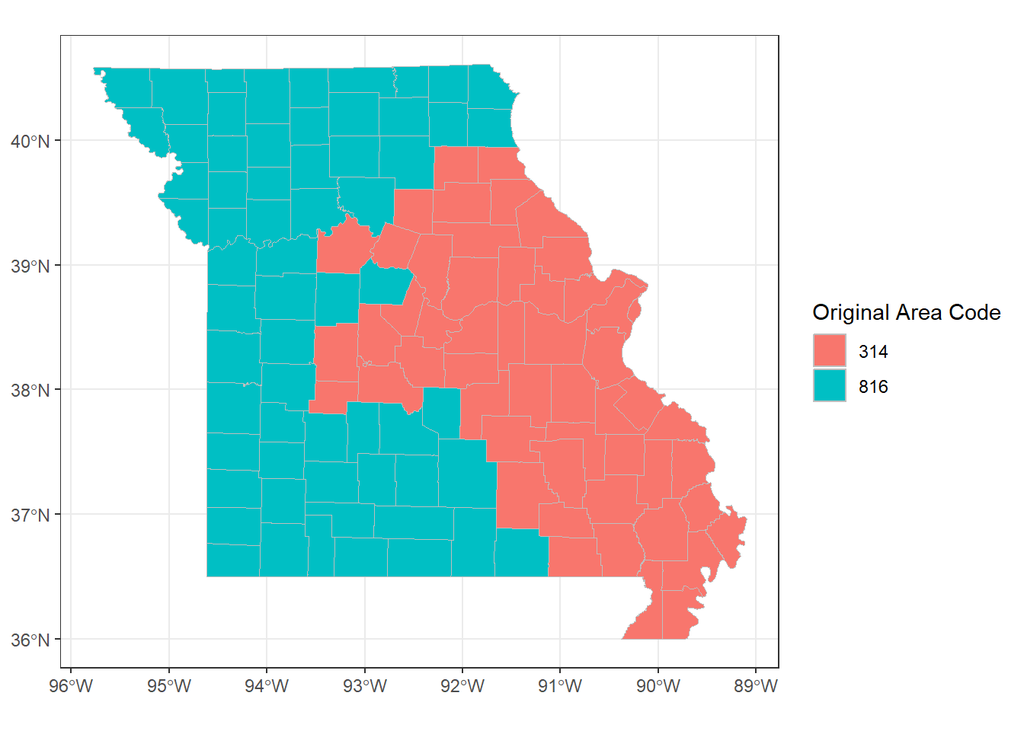

```r
#Missouri
ggplot() +
  geom_sf(data = missouri2,
          aes(fill = as.factor(original_area_code)),
          color = "grey") +
  labs(fill = "Original Area Code")
```

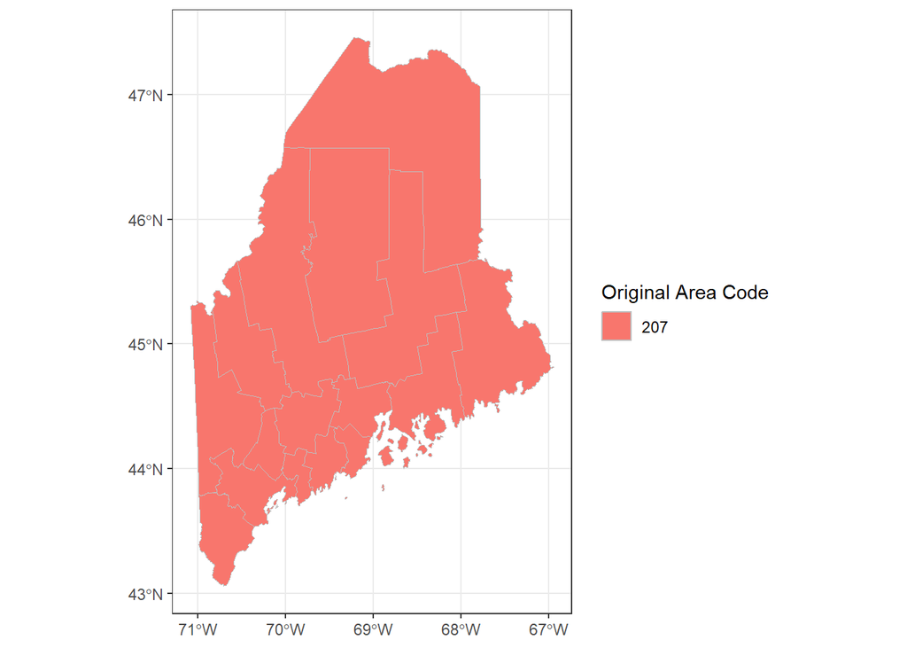

```r
#Maine
ggplot() +
  geom_sf(data = maine2,
          aes(fill = as.factor(original_area_code)),
          color = "grey") +
  labs(fill = "Original Area Code")
```

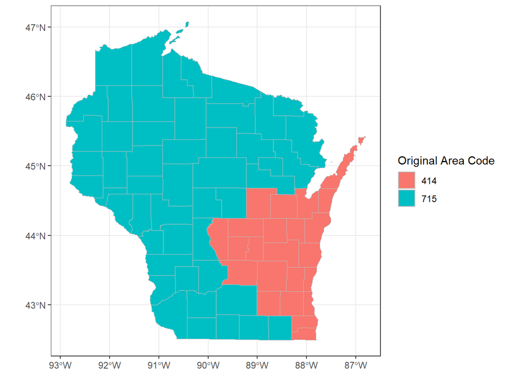

```r
#Wisconsin
ggplot() +
  geom_sf(data = wisconsin2,
          aes(fill = as.factor(original_area_code)),
          color = "grey") +
  labs(fill = "Original Area Code")
```

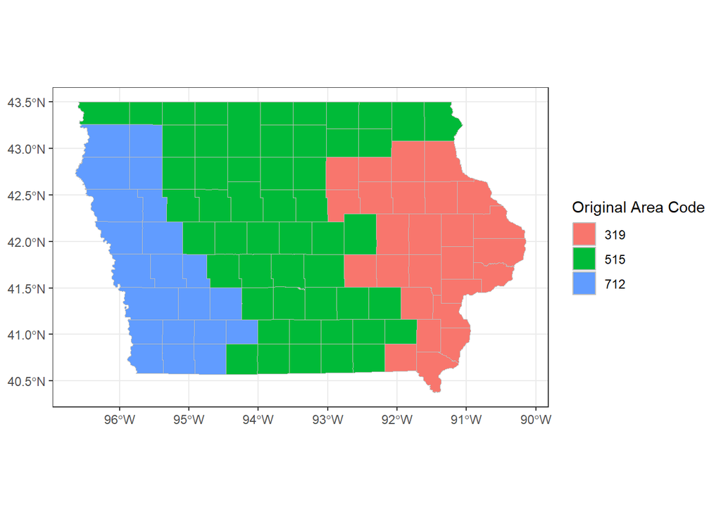

```r
#Final check—Iowa
ggplot() +
  geom_sf(data = iowa2,
          aes(fill = as.factor(original_area_code)),
          color = "grey") +
  labs(fill = "Original Area Code")
```

```r
#It worked!

# All the relevant city, state, and county pairings for new and old area codes
counties_area_codes_imputed <- counties_area_codes_sf_imputed |>
  select(new_area_code,
         original_area_code,
         original,
         city,
         state_or_province,
         NAME,
         STATE,
         COUNTY) |>
  st_drop_geometry() |>  #remove the special geometry attribute
  glimpse()
```

```
Rows: 5,309
Columns: 8
$ new_area_code      <int> 360, 701, 360, 218, 509, 360, 425, 425, 425, 425, 4…
$ original_area_code <fct> 206, 701, 206, 218, 206, 206, 206, 206, 206, 206, 2…
$ original           <lgl> FALSE, TRUE, FALSE, TRUE, FALSE, FALSE, FALSE, FALS…
$ city               <chr> "Bellingham", "Minot", "Mount Vernon", "Duluth", "W…
$ state_or_province  <chr> "Washington", "North Dakota", "Washington", "Minnes…
$ NAME               <chr> "Whatcom", "Ward", "Skagit", "St. Louis", "Chelan",…
$ STATE              <chr> "53", "38", "53", "27", "53", "53", "53", "53", "53…
$ COUNTY             <chr> "073", "101", "057", "137", "007", "061", "061", "0…
```

```r
# Write to csv
# write_csv(counties_area_codes_imputed, "data/counties_area_codes_imputed_final.csv")
```

## *Handle New and Merged Counties*

```r
 county_census_info <- county_census_info |> #counties present in 1950 consensus
   mutate(across(ends_with("_code"), parse_number)) |> #convert to numbersd to avoid conflict
   glimpse()
```

```
Rows: 3,123
Columns: 10
$ state_name                <chr> "alabama", "alabama", "alabama", "alabama", …
$ state_fips_code           <dbl> 1, 1, 1, 1, 1, 1, 1, 1, 1, 1, 1, 1, 1, 1, 1,…
$ county_fips_code          <dbl> 1, 3, 5, 7, 9, 11, 13, 15, 17, 19, 21, 23, 2…
$ county_name               <chr> "autauga", "baldwin", "barbour", "bibb", "bl…
$ population_1950           <dbl> 18186, 40997, 28892, 17987, 28975, 16054, 29…
$ residence_telephones_1945 <dbl> 274, 1026, 711, 191, 308, 253, 636, 3423, 20…
$ population_under5_1950    <dbl> 2342, 5449, 3984, 2286, 3513, 2179, 3859, 99…
$ population_over65_1950    <dbl> 1510, 3030, 2033, 1408, 1904, 1458, 2231, 43…
$ births                    <dbl> 510, 1312, 608, 332, 504, 366, 592, 2364, 78…
$ black_pop                 <dbl> 8366, 9224, 15428, 5828, 811, 11816, 13094, …
```

```r
#Read in and clean data, adding appropriate prefixes to making merging easier
merged_counties_since_1950 <- merged_counties_since_1950 |> #counties that have been merged
  mutate(across(ends_with("_fips"), parse_number)) |> #convert fips codes to numbers to avoid conflicts
  glimpse()
```

```
Rows: 16
Columns: 5
$ state_fips      <dbl> 13, 30, 32, 46, 46, 46, 51, 51, 51, 51, 51, 51, 51, 51…
$ old_county_fips <dbl> 510, 113, 25, 1, 131, 133, 55, 123, 129, 154, 189, 780…
$ new_county_fips <dbl> 121, 111, 510, 3, 71, 93, 550, 800, 710, 810, 700, 83,…
$ state           <chr> "georgia", "montana", "nevada", "south dakota", "south…
$ county          <chr> "columbus city", "yellowstone nat.", "ormsby", "armstr…
```

```r
new_counties_since_1950 <- new_counties_since_1950 |> #new counties that have been created
  mutate(across(ends_with("_fips"), parse_number)) |> #convert fips codes to numbers to avoid conflicts
  glimpse()
```

```
Rows: 2
Columns: 6
$ state           <chr> "new mexico", "arizona"
$ state_fips      <dbl> 35, 4
$ new_county_name <chr> "cibola", "la paz"
$ new_county_fips <dbl> 6, 12
$ old_county_name <chr> "valencia", "yuma"
$ old_county_fips <dbl> 61, 27
```

```r
# Before getting started reconciling my county data, I will clean 'counties_area_codes_imputed'
counties_area_codes_imputed <- counties_area_codes_imputed |>
  rename(current_state = state_or_province, #add 'current_' prefix
         current_county = NAME,
         current_state_fip = STATE,
         current_county_fip = COUNTY)

# Use regex to remove leading zeros
counties_area_codes_imputed <- counties_area_codes_imputed |>
  mutate(current_county_fip = str_remove(current_county_fip, "^0+")) |>
  mutate(across(ends_with("_fip"), parse_number)) |> #convert fips codes to numbers to avoid conflicts
  mutate(across(ends_with("county"), str_to_lower)) #lower state and county


counties_area_codes_imputed |> #includes current county data and associated area codes
  glimpse()
```

```
Rows: 5,309
Columns: 8
$ new_area_code      <int> 360, 701, 360, 218, 509, 360, 425, 425, 425, 425, 4…
$ original_area_code <fct> 206, 701, 206, 218, 206, 206, 206, 206, 206, 206, 2…
$ original           <lgl> FALSE, TRUE, FALSE, TRUE, FALSE, FALSE, FALSE, FALS…
$ city               <chr> "Bellingham", "Minot", "Mount Vernon", "Duluth", "W…
$ current_state      <chr> "Washington", "North Dakota", "Washington", "Minnes…
$ current_county     <chr> "whatcom", "ward", "skagit", "st. louis", "chelan",…
$ current_state_fip  <dbl> 53, 38, 53, 27, 53, 53, 53, 53, 53, 53, 53, 38, 53,…
$ current_county_fip <dbl> 73, 101, 57, 137, 7, 61, 61, 61, 61, 61, 61, 35, 63…
```

```r
# Illustrate that area codes that have since gotten new ones are already present
counties_area_codes_imputed |>
  inner_join(new_counties_since_1950,
            by = c("current_county_fip" = "old_county_fips",
                   "current_state_fip" = "state_fips")) |>
  select(original_area_code,
         old_county_name,
         new_county_name)
```

```
  original_area_code old_county_name new_county_name
1                602            yuma          la paz
2                602            yuma          la paz
3                505        valencia          cibola
```

```r
# Join the Counties that have been merged
counties_area_codes_imputed <- counties_area_codes_imputed |>
  left_join(merged_counties_since_1950,
           by = c("current_county_fip" = "new_county_fips",
                   "current_state_fip" = "state_fips")) |>
  glimpse()
```

```
Rows: 5,311
Columns: 11
$ new_area_code      <int> 360, 701, 360, 218, 509, 360, 425, 425, 425, 425, 4…
$ original_area_code <fct> 206, 701, 206, 218, 206, 206, 206, 206, 206, 206, 2…
$ original           <lgl> FALSE, TRUE, FALSE, TRUE, FALSE, FALSE, FALSE, FALS…
$ city               <chr> "Bellingham", "Minot", "Mount Vernon", "Duluth", "W…
$ current_state      <chr> "Washington", "North Dakota", "Washington", "Minnes…
$ current_county     <chr> "whatcom", "ward", "skagit", "st. louis", "chelan",…
$ current_state_fip  <dbl> 53, 38, 53, 27, 53, 53, 53, 53, 53, 53, 53, 38, 53,…
$ current_county_fip <dbl> 73, 101, 57, 137, 7, 61, 61, 61, 61, 61, 61, 35, 63…
$ old_county_fips    <dbl> NA, NA, NA, NA, NA, NA, NA, NA, NA, NA, NA, NA, NA,…
$ state              <chr> NA, NA, NA, NA, NA, NA, NA, NA, NA, NA, NA, NA, NA,…
$ county             <chr> NA, NA, NA, NA, NA, NA, NA, NA, NA, NA, NA, NA, NA,…
```

```r
counties_area_codes_imputed <- counties_area_codes_imputed |>
  left_join(county_census_info,
            by = c("current_county_fip" = "county_fips_code",
                   "current_state_fip" = "state_fips_code")) |>
  select(-c(state_name,
            county_name,
            #new_area_code
            ))

# Write to csv
# write_csv(counties_area_codes_imputed, "data/counties_area_codes_imputed_with_censensus_final.csv")
```

```r
# Custom dial pull function
dial_pull <- function(area_code){

  # Split area code digits
  area_code_digits <- strsplit(as.character(area_code), "")[[1]]

  # Ensure digits are integers
  dial_pull_values <- as.integer(area_code_digits)

  # calculate the dial pull
  dial_pull_values <- ifelse(dial_pull_values == 0,
                             10, #zero is special case
                             dial_pull_values) #otherwise number

  # Sum the dial pulls for the three digits
  total_dial_pulls <- sum(dial_pull_values)

  return(total_dial_pulls)
}

# test function to ensure expected values
dial_pull("212")
```

```
[1] 5
```

```r
dial_pull("412")
```

```
[1] 7
```

```r
dial_pull("902")
```

```
[1] 21
```

```r
# Apply function
counties_area_codes_imputed <- counties_area_codes_imputed |>
  rowwise() |>
  mutate(dial_pulls = dial_pull(original_area_code))

counties_area_codes_imputed |>
  glimpse()
```

```
Rows: 5,311
Columns: 18
Rowwise:
$ new_area_code             <int> 360, 701, 360, 218, 509, 360, 425, 425, 425,…
$ original_area_code        <fct> 206, 701, 206, 218, 206, 206, 206, 206, 206,…
$ original                  <lgl> FALSE, TRUE, FALSE, TRUE, FALSE, FALSE, FALS…
$ city                      <chr> "Bellingham", "Minot", "Mount Vernon", "Dulu…
$ current_state             <chr> "Washington", "North Dakota", "Washington", …
$ current_county            <chr> "whatcom", "ward", "skagit", "st. louis", "c…
$ current_state_fip         <dbl> 53, 38, 53, 27, 53, 53, 53, 53, 53, 53, 53, …
$ current_county_fip        <dbl> 73, 101, 57, 137, 7, 61, 61, 61, 61, 61, 61,…
$ old_county_fips           <dbl> NA, NA, NA, NA, NA, NA, NA, NA, NA, NA, NA, …
$ state                     <chr> NA, NA, NA, NA, NA, NA, NA, NA, NA, NA, NA, …
$ county                    <chr> NA, NA, NA, NA, NA, NA, NA, NA, NA, NA, NA, …
$ population_1950           <dbl> 66733, 34782, 43273, 206062, 39301, 111580, …
$ residence_telephones_1945 <dbl> 10994, 4651, 6201, 33643, 5715, 13120, 13120…
$ population_under5_1950    <dbl> 7053, 4097, 4271, 21487, 4412, 12243, 12243,…
$ population_over65_1950    <dbl> 7468, 2844, 4977, 20272, 3265, 11606, 11606,…
$ births                    <dbl> 1298, 1494, 1034, 5426, 858, 3992, 3992, 399…
$ black_pop                 <dbl> 1068, 209, 519, 1442, 118, 781, 781, 781, 78…
$ dial_pulls                <dbl> 18, 18, 18, 11, 18, 18, 18, 18, 18, 18, 18, …
```

```r
# get total population and black population, calulating the percent black
area_code_summary <- counties_area_codes_imputed |>
  distinct(original_area_code,
         current_county,
         population_1950,
         black_pop,
         current_county_fip) |>
  group_by(original_area_code) |>
  summarize(total_population = sum(population_1950,
                                   na.rm = TRUE),
            black_pop = sum(black_pop,
                            na.rm = TRUE)) |>
  rowwise() |>
  mutate(dial_pulls = dial_pull(original_area_code),
         percent_black = (black_pop / total_population))


# Write to csv
# write_csv(area_code_summary, "data/area_code_summary.csv")

# Write to csv
# write_csv(counties_area_codes_imputed, "data/counties_area_codes_imputed_with_dial_pulls_final.csv")
```

```r
# write_csv(counties_area_codes_imputed, "data/counties_area_codes_imputed_with_population_final.csv")

#number of NA new area codes
is.na(counties_area_codes_imputed$new_area_code) |>
  sum()
```

```
[1] 2621
```

```r
new_area_code_summary <- counties_area_codes_imputed |>
  distinct(new_area_code, original_area_code) |>
  group_by(original_area_code) |>
  summarize(
    unique_count = n_distinct(new_area_code, na.rm = TRUE))

new_area_code_summary
```

```
# A tibble: 77 × 2
   original_area_code unique_count
   <fct>                     <int>
 1 201                           9
 2 202                           1
 3 203                           3
 4 205                           4
 5 206                           5
 6 207                           1
 7 208                           1
 8 212                           6
 9 213                          19
10 214                           8
# ℹ 67 more rows
```

## Predicting new area codes with random forest

```r
# Read in counties simple features again
counties_sf <- st_read("data/co99_d00_shp/co99_d00.shp") |>
  mutate(STATE = parse_number(STATE),
         COUNTY = parse_number(COUNTY)) |>
  mutate(NAME = str_to_lower(NAME)) #lower state and county
# Join counties_sf with counties_area_codes_imputed
counties_area_codes_sf <- counties_area_codes_imputed |>
  left_join(counties_sf,
            by = c("current_county" = "NAME",
                   "current_state_fip" = "STATE",
                   "current_county_fip" = "COUNTY")) |>
  distinct(new_area_code,
           original_area_code,
           original,
           city,
           current_state,
           current_county,
           current_state_fip,
           current_county_fip,
           population_1950,
           AREA,
           PERIMETER,
           geometry) |>
  glimpse()
```

```
Rows: 6,001
Columns: 12
Rowwise:
$ new_area_code      <int> 360, 360, 360, 701, 360, 360, 360, 360, 218, 509, 3…
$ original_area_code <fct> 206, 206, 206, 701, 206, 206, 206, 206, 218, 206, 2…
$ original           <lgl> FALSE, FALSE, FALSE, TRUE, FALSE, FALSE, FALSE, FAL…
$ city               <chr> "Bellingham", "Bellingham", "Bellingham", "Minot", …
$ current_state      <chr> "Washington", "Washington", "Washington", "North Da…
$ current_county     <chr> "whatcom", "whatcom", "whatcom", "ward", "skagit", …
$ current_state_fip  <dbl> 53, 53, 53, 38, 53, 53, 53, 53, 27, 53, 53, 53, 53,…
$ current_county_fip <dbl> 73, 73, 73, 101, 57, 57, 57, 57, 137, 7, 61, 61, 61…
$ population_1950    <dbl> 66733, 66733, 66733, 34782, 43273, 43273, 43273, 43…
$ AREA               <dbl> 0.6839443860, 0.0015208537, 0.0029648757, 0.6445463…
$ PERIMETER          <dbl> 5.32688084, 0.17436049, 0.32785881, 4.44401324, 5.4…
$ geometry           <POLYGON> POLYGON ((-122.2907 49.0024..., POLYGON ((-123.…
```

```r
counties_area_codes_sf <- counties_area_codes_sf |>
  mutate(centroid = st_centroid(geometry) |>
           st_coordinates(),
         centroid_lat = centroid[,2],
         centroid_long = centroid[,1]) |>
  mutate(original_area_code = as.factor(original_area_code)) #prepare for modeling
```

```r
set.seed(4)

counties_area_codes_sf <-  counties_area_codes_sf |>
  mutate(new_area_code = as.factor(new_area_code),
         original_area_code = as.character(original_area_code),
         original = as.character(original)) |>
  filter(!is.na(population_1950)) |>
  glimpse()
```

```
Rows: 5,909
Columns: 15
Rowwise:
$ new_area_code      <fct> 360, 360, 360, 701, 360, 360, 360, 360, 218, 509, 3…
$ original_area_code <chr> "206", "206", "206", "701", "206", "206", "206", "2…
$ original           <chr> "FALSE", "FALSE", "FALSE", "TRUE", "FALSE", "FALSE"…
$ city               <chr> "Bellingham", "Bellingham", "Bellingham", "Minot", …
$ current_state      <chr> "Washington", "Washington", "Washington", "North Da…
$ current_county     <chr> "whatcom", "whatcom", "whatcom", "ward", "skagit", …
$ current_state_fip  <dbl> 53, 53, 53, 38, 53, 53, 53, 53, 27, 53, 53, 53, 53,…
$ current_county_fip <dbl> 73, 73, 73, 101, 57, 57, 57, 57, 137, 7, 61, 61, 61…
$ population_1950    <dbl> 66733, 66733, 66733, 34782, 43273, 43273, 43273, 43…
$ AREA               <dbl> 0.6839443860, 0.0015208537, 0.0029648757, 0.6445463…
$ PERIMETER          <dbl> 5.32688084, 0.17436049, 0.32785881, 4.44401324, 5.4…
$ geometry           <POLYGON> POLYGON ((-122.2907 49.0024..., POLYGON ((-123.…
$ centroid           <dbl[,2]> <matrix[26 x 2]>
$ centroid_lat       <dbl> 48.82591, 48.98870, 48.69410, 48.22180, 48.4784…
$ centroid_long      <dbl> -121.71371, -123.05693, -122.66655, -101.54187, -12…
```

```r
# Partition data based on NAs

# Test data are rows with NAs for original_area_codes
test_data <- counties_area_codes_sf |>
  filter(is.na(new_area_code)) |>
  glimpse()
```

```
Rows: 2,573
Columns: 15
Rowwise:
$ new_area_code      <fct> NA, NA, NA, NA, NA, NA, NA, NA, NA, NA, NA, NA, NA,…
$ original_area_code <chr> "218", "206", "206", "206", "406", "406", "208", "4…
$ original           <chr> NA, NA, NA, NA, NA, NA, NA, NA, NA, NA, NA, NA, NA,…
$ city               <chr> NA, NA, NA, NA, NA, NA, NA, NA, NA, NA, NA, NA, NA,…
$ current_state      <chr> NA, NA, NA, NA, NA, NA, NA, NA, NA, NA, NA, NA, NA,…
$ current_county     <chr> "lake of the woods", "whatcom", "whatcom", "whatcom…
$ current_state_fip  <dbl> 27, 53, 53, 53, 30, 30, 16, 30, 53, 53, 38, 27, 30,…
$ current_county_fip <dbl> 77, 73, 73, 73, 29, 53, 21, 5, 65, 47, 67, 69, 41, …
$ population_1950    <dbl> 4955, 66733, 66733, 66733, 31495, 8693, 5908, 8516,…
$ AREA               <dbl> 0.562393279, 0.683944386, 0.001520854, 0.002964876,…
$ PERIMETER          <dbl> 4.2540510, 5.3268808, 0.1743605, 0.3278588, 8.65854…
$ geometry           <POLYGON> POLYGON ((-95.15332 49.1931..., POLYGON ((-122.…
$ centroid           <dbl[,2]> <matrix[26 x 2]>
$ centroid_lat       <dbl> 48.77060, 48.82591, 48.98870, 48.69410, 48.2951…
$ centroid_long      <dbl> -94.90497, -121.71371, -123.05693, -122.66655, -114…
```

```r
# Train data are rows with no NAs for original_area_codes
train_data <- counties_area_codes_sf |>
  filter(!is.na(new_area_code)) |>
  glimpse()
```

```
Rows: 3,336
Columns: 15
Rowwise:
$ new_area_code      <fct> 360, 360, 360, 701, 360, 360, 360, 360, 218, 509, 3…
$ original_area_code <chr> "206", "206", "206", "701", "206", "206", "206", "2…
$ original           <chr> "FALSE", "FALSE", "FALSE", "TRUE", "FALSE", "FALSE"…
$ city               <chr> "Bellingham", "Bellingham", "Bellingham", "Minot", …
$ current_state      <chr> "Washington", "Washington", "Washington", "North Da…
$ current_county     <chr> "whatcom", "whatcom", "whatcom", "ward", "skagit", …
$ current_state_fip  <dbl> 53, 53, 53, 38, 53, 53, 53, 53, 27, 53, 53, 53, 53,…
$ current_county_fip <dbl> 73, 73, 73, 101, 57, 57, 57, 57, 137, 7, 61, 61, 61…
$ population_1950    <dbl> 66733, 66733, 66733, 34782, 43273, 43273, 43273, 43…
$ AREA               <dbl> 0.6839443860, 0.0015208537, 0.0029648757, 0.6445463…
$ PERIMETER          <dbl> 5.32688084, 0.17436049, 0.32785881, 4.44401324, 5.4…
$ geometry           <POLYGON> POLYGON ((-122.2907 49.0024..., POLYGON ((-123.…
$ centroid           <dbl[,2]> <matrix[26 x 2]>
$ centroid_lat       <dbl> 48.82591, 48.98870, 48.69410, 48.22180, 48.4784…
$ centroid_long      <dbl> -121.71371, -123.05693, -122.66655, -101.54187, -12…
```

```r
# Create workflow
rf_recipe <- recipe(new_area_code ~
                        current_county +
                        current_state_fip +
                        current_county_fip +
                        centroid_lat +
                        centroid_long +
                        AREA +
                        original_area_code,
                      data = train_data) |>
  step_novel(all_nominal_predictors()) |>
  step_dummy(all_nominal_predictors()) |>
  step_zv(all_predictors()) |>
  step_normalize(all_predictors())


classification_rf <- rand_forest() |>
  set_engine("ranger") |>
  set_mode("classification")

workflow_rf <- workflow() |>
  add_model(classification_rf) |>
  add_recipe(rf_recipe)

# Fit the model
workflow_rf_fit <- workflow_rf |>
  fit(train_data)

# Predict the original area code on the test partition
workflow_rf_preds <- workflow_rf_fit |>
  predict(test_data)

workflow_rf_preds
```

```
# A tibble: 2,573 × 1
   .pred_class
   <fct>
 1 218
 2 425
 3 360
 4 360
 5 406
 6 406
 7 208
 8 406
 9 425
10 425
# ℹ 2,563 more rows
```

```r
area_code_data <- test_data |>
  bind_cols(workflow_rf_preds) |>
  select(-new_area_code) |>  #drop NAs
  rename(new_area_code = .pred_class) |>
  relocate(new_area_code,
           .before = 2)
```